# Portfolio Master - 45197083

## COMP257 - Data Science

#### Assessment Task: Portfolio

#### Weighting: 20%

#### Student Name: Justin Lam

#### Student Number: 45197083

Description: The portfolio assessment will consist of three small data analysis problems that you will be given through the semester. These will involve writing code to analyse one or more data sets. You will show the versions in the workshops in weeks 4, 6 and 8 and then submit a final version in week 10 as an assignment for the final 20%.

## Portfolio 1

Description: The first dataset is an export of my ride data from [Strava](https://strava.com/), an online social network site for cycling and other sports. This data is a log of every ride since the start of 2018 and contains summary data like the distance and average speed. It was exported using the script `stravaget.py` which uses the stravalib module to read data. Some details of the fields exported by that script can be seen in [the documentation for stravalib](https://pythonhosted.org/stravalib/api.html#stravalib.model.Activity).

The exported data is a CSV file so that's easy to read, however the date information in the file is recorded in a different timezone (UTC) so we need to do a bit of conversion. In reading the data I'm setting the index of the data frame to be the datetime of the ride.

#### Import Relevant Packages

```python
import pandas as pd
from matplotlib import pyplot as plt
from datetime import timedelta
import seaborn as sns
import numpy as np
import datetime as dt
from datetime import datetime
plt.style.use('seaborn')
%matplotlib inline
from scipy import stats
```

#### Loading Data

There are two datasets in this portfolio - both Strava and Cheetah.

```python
strava = pd.read_csv('strava_export.csv', index_col='date', parse_dates=True)
strava.index = strava.index.tz_convert('Australia/Sydney')
strava.head()
```

| date | average_heartrate | average_temp | average_watts | device_watts | distance | elapsed_time | elevation_gain | kudos | moving_time | workout_type |
| --- | --- | --- | --- | --- | --- | --- | --- | --- | --- | --- |
| 2018-01-03 07:47:51+11:00 | 100.6 | 21.0 | 73.8 | False | 15.2 | 94 | 316.00 m | 10 | 73 | Ride |
| 2018-01-04 12:36:53+11:00 | NaN | 24.0 | 131.7 | False | 18.0 | 52 | 236.00 m | 5 | 46 | Ride |
| 2018-01-04 13:56:00+11:00 | 83.1 | 25.0 | 13.8 | False | 0.0 | 3 | 0.00 m | 2 | 2 | Ride |
| 2018-01-04 16:37:04+11:00 | 110.1 | 24.0 | 113.6 | False | 22.9 | 77 | 246.00 m | 8 | 64 | Ride |
| 2018-01-06 06:22:46+11:00 | 110.9 | 20.0 | 147.7 | True | 58.4 | 189 | 676.00 m | 12 | 144 | Ride |

The second dataset comes from an application called [GoldenCheetah](https://www.goldencheetah.org/) which provides some analytics services over ride data. This has some of the same fields but adds a lot of analysis of the power, speed and heart rate data in each ride. This data overlaps with the Strava data but doesn't include all of the same rides.

Again we create an index using the datetime for each ride, this time combining two columns in the data (date and time) and localising to Sydney so that the times match those for the Strava data.

```python
cheetah = pd.read_csv('cheetah.csv', skipinitialspace=True)
cheetah.index = pd.to_datetime(cheetah['date'] + ' ' + cheetah['time'])
cheetah.index = cheetah.index.tz_localize('Australia/Sydney')
cheetah.head()
```

|  | date | time | filename | axPower | aPower Relative Intensity | aBikeScore | Skiba aVI | aPower Response Index | aIsoPower | aIF | ... | Rest AVNN | Rest SDNN | Rest rMSSD | Rest PNN50 | Rest LF | Rest HF | HRV Recovery Points | NP | IF | TSS |
| --- | --- | --- | --- | --- | --- | --- | --- | --- | --- | --- | --- | --- | --- | --- | --- | --- | --- | --- | --- | --- | --- |
| 2018-01-28 06:39:49+11:00 | 01/28/18 | 06:39:49 | 2018_01_28_06_39_49.json | 202.211 | 0.75452 | 16.6520 | 1.31920 | 1.67755 | 223.621 | 0.83441 | ... | 0 | 0 | 0 | 0 | 0 | 0 | 0 | 222.856 | 0.83155 | 20.2257 |
| 2018-01-28 07:01:32+11:00 | 01/28/18 | 07:01:32 | 2018_01_28_07_01_32.json | 226.039 | 0.84343 | 80.2669 | 1.21137 | 1.54250 | 246.185 | 0.91860 | ... | 0 | 0 | 0 | 0 | 0 | 0 | 0 | 245.365 | 0.91554 | 94.5787 |
| 2018-02-01 08:13:34+11:00 | 02/01/18 | 08:13:34 | 2018_02_01_08_13_34.json | 0.000 | 0.00000 | 0.0000 | 0.00000 | 0.00000 | 0.000 | 0.00000 | ... | 0 | 0 | 0 | 0 | 0 | 0 | 0 | 0.000 | 0.00000 | 0.0000 |
| 2018-02-06 08:06:42+11:00 | 02/06/18 | 08:06:42 | 2018_02_06_08_06_42.json | 221.672 | 0.82714 | 78.8866 | 1.35775 | 1.86002 | 254.409 | 0.94929 | ... | 0 | 0 | 0 | 0 | 0 | 0 | 0 | 253.702 | 0.94665 | 98.3269 |
| 2018-02-07 17:59:05+11:00 | 02/07/18 | 17:59:05 | 2018_02_07_17_59_05.json | 218.211 | 0.81422 | 159.4590 | 1.47188 | 1.74658 | 233.780 | 0.87231 | ... | 0 | 0 | 0 | 0 | 0 | 0 | 0 | 232.644 | 0.86808 | 171.0780 |

5 rows × 362 columns

The definitions of some of the important variables are described below. Capitalised fields come from the GoldenCheetah data while lowercase_fields come from Strava. There are many cases where fields are duplicated and in this case the values should be the same, although there is room for variation as the algorithm used to calculate them could be different in each case.

- Duration - overall duration of the ride, should be same as elapsed_time
- Time Moving - time spent moving (not resting or waiting at lights), should be the same as moving_time
- Elevation Gain - metres climbed over the ride
- Average Speed - over the ride
- Average Power - average power in watts as measured by a power meter, relates to how much effort is being put in to the ride, should be the same as * average_watts' from Strava
- Nonzero Average Power - same as Average Power but excludes times when power is zero from the average
- Average Heart Rate - should be the same as average_heartrate
- Average Cadence - cadence is the rotations per minute of the pedals
- Average Temp - temperature in the environment as measured by the bike computer (should be same as average_temp)
- VAM - average ascent speed - speed up hills
- Calories (HR) - Calorie expendature as estimated from heart rate data
- 1 sec Peak Power - this and other 'Peak Power' measures give the maximum power output in the ride over this time period. Will be higher for shorter periods. High values in short periods would come from a very 'punchy' ride with sprints for example.
- 1 min Peak Hr - a similar measure relating to Heart Rate
- NP - Normalised Power, a smoothed average power measurement, generally higher than Average Power
- TSS - Training Stress Score, a measure of how hard a ride this was
- device_watts - True if the power (watts) measures were from a power meter, False if they were estimated
- distance - distance travelled in Km
- kudos - likes from other Strava users (social network)
- workout_type - one of 'Race', 'Workout' or 'Ride'

Some of the GoldenCheetah parameters are defined [in thier documentation](https://github.com/GoldenCheetah/GoldenCheetah/wiki/UG_Glossary).

#### Required Analysis

1. Remove rides with no measured power (where device_watts is False) - these are commutes or MTB rides
- Look at the distributions of some key variables: time, distance, average speed, average power, TSS. Are they normally distributed? Skewed?
- Explore the relationships between the following variables. Are any of them corrolated with each other (do they vary together in a predictable way)? Can you explain any relationships you observe?
  - Distance
  - Moving Time
  - Average Speed
  - Heart Rate
  - Power (watts)
  - Normalised power (NP)
  - Training Stress Score
  - Elevation Gain
- We want to explore the differences between the three categories: `Race`, `Workout` and `Ride`.
  - Use scatter plots with different colours for each category to explore how these categories differ.
  - Use histograms or box plots to visualise the different distributions of a variable for the three categories.
  - In both cases, experiment with different variables but only include those that are interesting in your final notebook (if none are interesting, show us a representative example).

#### Challenge

- What leads to more `kudos`? Is there anything to indicate which rides are more popular? Explore the relationship between the main variables and kudos. Show a plot and comment on any relationship you observe.
- Generate a plot that summarises the number of km ridden each month over the period of the data. Overlay this with the *sum* of the Training Stress Score and the *average* of the Average Speed to generate an overall summary of activity.
- Generate a similar graph but one that shows the activity over a given month, with the sum of the values for each day of the month shown. So, if there are two rides on a given day, the graph should show the sum of the distances etc for these rides.

Hint: to generate these summary plots you need to use the [timeseries/date functionality](https://pandas.pydata.org/pandas-docs/stable/user_guide/timeseries.html) in Pandas to generate a new data frame containing the required data.

**Note:** once you have completed these steps you can remove this cell. Use the text as a starting point for the documentation of your workflow and discussion of results.

#### Joining the tables together.

We are going to combine both Strava and Cheeth by using the inner.join function on Python.

```python
df = strava.join(cheetah, how='inner')
df.shape
```

```
(243, 372)
```

#### Question 1

```python
dw_false = df.loc[df['device_watts'] == False].index #Select the variable where it matches with the requirement of the question.
df.drop(dw_false , inplace=True)
df.head()
```

|  | average_heartrate | average_temp | average_watts | device_watts | distance | elapsed_time | elevation_gain | kudos | moving_time | workout_type | ... | Rest AVNN | Rest SDNN | Rest rMSSD | Rest PNN50 | Rest LF | Rest HF | HRV Recovery Points | NP | IF | TSS |
| --- | --- | --- | --- | --- | --- | --- | --- | --- | --- | --- | --- | --- | --- | --- | --- | --- | --- | --- | --- | --- | --- |
| 2018-01-28 06:39:49+11:00 | 120.6 | 21.0 | 153.4 | True | 7.6 | 17 | 95.00 m | 4 | 17 | Ride | ... | 0 | 0 | 0 | 0 | 0 | 0 | 0 | 222.856 | 0.83155 | 20.2257 |
| 2018-01-28 07:01:32+11:00 | 146.9 | 22.0 | 187.7 | True | 38.6 | 67 | 449.00 m | 19 | 67 | Race | ... | 0 | 0 | 0 | 0 | 0 | 0 | 0 | 245.365 | 0.91554 | 94.5787 |
| 2018-02-06 08:06:42+11:00 | 119.3 | 19.0 | 165.9 | True | 24.3 | 69 | 439.00 m | 6 | 65 | Ride | ... | 0 | 0 | 0 | 0 | 0 | 0 | 0 | 253.702 | 0.94665 | 98.3269 |
| 2018-02-07 17:59:05+11:00 | 124.8 | 20.0 | 151.0 | True | 47.1 | 144 | 890.00 m | 10 | 134 | Ride | ... | 0 | 0 | 0 | 0 | 0 | 0 | 0 | 232.644 | 0.86808 | 171.0780 |
| 2018-02-10 06:18:03+11:00 | 123.0 | 20.0 | 145.9 | True | 59.8 | 193 | 656.00 m | 22 | 139 | Ride | ... | 0 | 0 | 0 | 0 | 0 | 0 | 0 | 212.726 | 0.79375 | 147.7970 |

5 rows × 372 columns

#### Question 2

A histogam is created for the variable time. The number of bin of the histogram have been set to 24 - which represents 24 hours.

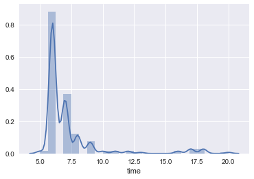

```python
time = pd.to_datetime(df['time'])
hour = time.dt.hour
sns.distplot(hour, bins = 24)
```

Comment: A histogram is generated to measure the distribution the variable 'Distance'. By looking at the skewness of the histogram, it suggests that the distribution is moderately right skewed.

```
The skewness of the variable 'Distance' is 0.5198700561050731
```

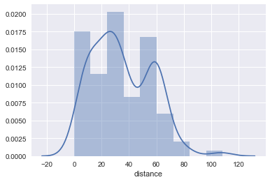

```python
distance = df['distance']
sns.distplot(distance)
print ("The skewness of the variable 'Distance' is", distance.skew())
```

```
The skewness of the variable 'Average_Power' is -0.8383509023831505
```

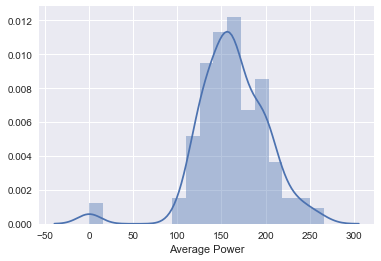

```python
power = df['Average Power']
sns.distplot(power)
print ("The skewness of the variable 'Average_Power' is", power.skew())
```

```
The skewness of the variable 'TSS (Training Stress Score)' is 1.055780702424325
```

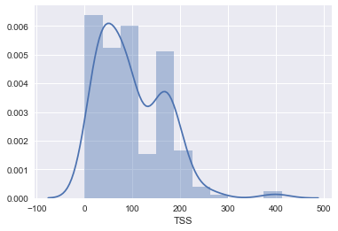

```python
tss = df['TSS']
sns.distplot(tss)
print ("The skewness of the variable 'TSS (Training Stress Score)' is", tss.skew())
```

Comment: Based on the measurement of skewness above, it appears that the distribution of the variable 'TSS' (Train Stress Score) is highly right skewed.

```
The skewness of the variable 'Average Speed' is -0.5673884445402874
```

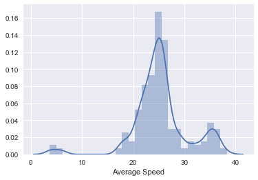

```python
speed = df['Average Speed']
sns.distplot(speed)
print ("The skewness of the variable 'Average Speed' is", speed.skew())
```

#### Question 3

A correlation matrix of the selected variables is created.

```python
q3 = df[['distance','moving_time','Average Speed','Heartbeats','Average Power','NP','TSS', 'Elevation Gain']]
q3.corr()
```

|  | distance | moving_time | Average Speed | Heartbeats | Average Power | NP | TSS | Elevation Gain |
| --- | --- | --- | --- | --- | --- | --- | --- | --- |
| distance | 1.000000 | 0.939383 | 0.187363 | 0.874668 | 0.129199 | 0.270703 | 0.922565 | 0.805468 |
| moving_time | 0.939383 | 1.000000 | -0.103484 | 0.839142 | -0.109838 | 0.044431 | 0.871368 | 0.813146 |
| Average Speed | 0.187363 | -0.103484 | 1.000000 | 0.088658 | 0.814403 | 0.674857 | 0.134054 | -0.016160 |
| Heartbeats | 0.874668 | 0.839142 | 0.088658 | 1.000000 | 0.103347 | 0.238983 | 0.842333 | 0.745196 |
| Average Power | 0.129199 | -0.109838 | 0.814403 | 0.103347 | 1.000000 | 0.844487 | 0.225290 | -0.035987 |
| NP | 0.270703 | 0.044431 | 0.674857 | 0.238983 | 0.844487 | 1.000000 | 0.432286 | 0.229933 |
| TSS | 0.922565 | 0.871368 | 0.134054 | 0.842333 | 0.225290 | 0.432286 | 1.000000 | 0.828928 |
| Elevation Gain | 0.805468 | 0.813146 | -0.016160 | 0.745196 | -0.035987 | 0.229933 | 0.828928 | 1.000000 |

#### Correlation Interpretation

Correlation is used to measure the strength of the relatationship between two variables. Based on the above correlation matrix, we can concluded that the following variables are highly correlated/has a strong linear relationship (correlation coefficient > 0.7).

1. Distance and Moving Time
2. Distance and HeartBeats
3. Distnace and TSS (Total Stress Score)
4. Distance and Elevation Gain
5. Moving Time and Heartbeats
6. Moving Time and TSS
7. Moving Time and Elevation Gain
8. Average Speed and Average Watts
9. Heartbeats and TSS
10. Heartbeats and Elevation Gain
11. Average Watts and NP (Normalised Power)
12. TSS and Elevation Gain
13. NP and Average Power

There is no suprise to see there is a strong correlation between distance and moving_time - which means the fact that the greater the distance, it will takes them longer to ride.

On the other hand,it is interesting to see there is a weak correaltion between the average speed and heartbeats as I thought "If the cyclist rides in a faster speed then it will most likely to result a higher heartbeat - in fact this is not the case." Furthermore, it is interesting to see that the cyclist's heartbeat does not corrleated with the speed of the cyclist.

Note: Negative correlation != Negative Relationship. However it means that there is an invese relationship between the two variables.

#### Question 4

Interesting Graphs for each of the each of the categories:

1. Distance and Moving_Time
2. Average Speed and Heartbeats
3. Heartbeats and Average Speed

Before we create any graphs, we need to extract the data from the columns. As you can see below, there are three different types of workout types: race, workout and ride.

```python
race = df[df['workout_type'] == 'Race']
workout = df[df['workout_type'] == 'Workout']
ride = df[df['workout_type'] == 'Ride']
```

The first plot that we are generating is scatter plot as it will allow us to interpret the trends of the data and it will also allow us to explore each of the workout types differ.

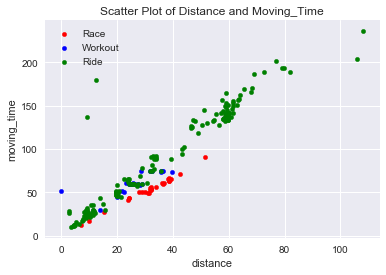

```python
ax1 = race.plot(kind='scatter', x = 'distance', y = 'moving_time', color = 'red', title = 'Scatter Plot of Distance and Moving_Time')
ax2 = workout.plot(kind='scatter', x = 'distance', y = 'moving_time', color = 'blue', ax = ax1)
ax3 = ride.plot(kind='scatter', x = 'distance', y = 'moving_time', color = 'green', ax = ax1)
ax1.legend(['Race', 'Workout', 'Ride'])
```

Comment: It looks like there is a strong relationship between the rider's distance and the moving time of the rider. Some outliers are evident for the one who did riding as his exercise.

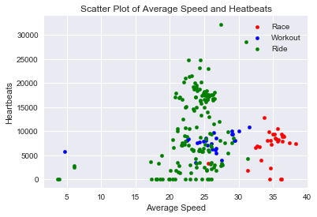

```python
ax4 = race.plot(kind='scatter', x = 'Average Speed', y = 'Heartbeats', color = 'red', title = 'Scatter Plot of Average Speed and Heatbeats')
ax5 = workout.plot(kind='scatter', x = 'Average Speed', y = 'Heartbeats', color = 'blue', ax = ax4)
ax6 = ride.plot(kind='scatter', x = 'Average Speed', y = 'Heartbeats', color = 'green', ax = ax4)
ax4.legend(['Race', 'Workout', 'Ride'])
```

Comment: Based on the correlation matrix we generated, we are expected a random scatter between variables 'Average Speed' and' Heartbeats' due to the low correlation.

[figure not shown]

```python
ax7 = race.plot(kind='scatter', x = 'Heartbeats', y = 'Average Speed', color = 'red',title = 'Scatter Plot of Distance and Average Speed')
ax8 = workout.plot(kind='scatter', x = 'Heartbeats', y = 'Average Speed', color = 'blue', ax = ax7)
ax9 = ride.plot(kind='scatter', x = 'Heartbeats', y = 'Average Speed', color = 'green', ax = ax7)
ax7.legend(['Race', 'Workout', 'Ride'])
```

b) Use histograms or box plots to visualise the different distributions of a variable for the three categories.

```python
distance = [race.distance, ride.distance, workout.distance]
move = [race.moving_time, ride.moving_time, workout.moving_time]
speed = [race['Average Speed'], ride['Average Speed'], workout['Average Speed']]
heartrate = [race.Heartbeats, ride.Heartbeats, workout.Heartbeats]
power = [race['Average Power'], ride['Average Power'], workout['Average Power']]
NP = [race.NP, ride.NP, workout.NP]
TSS = [race.TSS, ride.TSS, workout.TSS]
EGain = [race['Elevation Gain'], ride['Elevation Gain'], workout['Elevation Gain']]
```

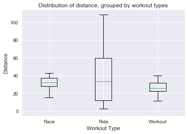

```python
plt.boxplot(distance)
plt.xlabel('Workout Type')
plt.ylabel('Distance')
plt.xticks([1, 2, 3], ['Race', 'Ride', 'Workout'])
plt.title('Distribution of distance, grouped by workout types')
```

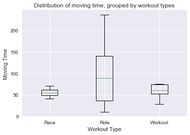

```python
plt.boxplot(move)
plt.xlabel('Workout Type')
plt.ylabel('Moving Time')
plt.xticks([1, 2, 3], ['Race', 'Ride', 'Workout'])
plt.title('Distribution of moving time, grouped by workout types')
```

Comment: Both Race and Workout appears to have a similar median in moving time, while the boxplot between variables 'Ride' and 'Moving Time' is comparatively tall.

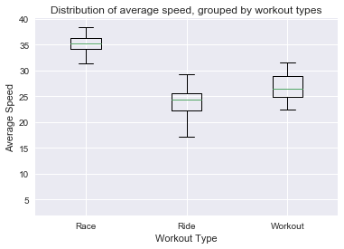

```python
plt.boxplot(speed)
plt.xlabel('Workout Type')
plt.ylabel('Average Speed')
plt.xticks([1, 2, 3], ['Race', 'Ride', 'Workout'])
plt.title('Distribution of average speed, grouped by workout types')
```

Comment: It is evident that the average speed is the highest for workout type 'Race' while workout type 'ride' has the slowest average speed. There is also an obvious difference between all of the boxplots - with each of them have different medians.

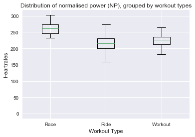

```python
plt.boxplot(NP)
plt.xlabel('Workout Type')
plt.ylabel('Heartrates')
plt.xticks([1, 2, 3], ['Race', 'Ride', 'Workout'])
plt.title('Distribution of normalised power (NP), grouped by workout types')
```

Comment: Unsurprisingly, 'Race' generates the greatest amount of energy however it is surprising to see the median normalised power between 'Ride' and 'Workout'are similar.

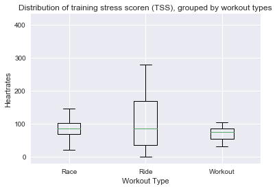

```python
plt.boxplot(TSS)
plt.xlabel('Workout Type')
plt.ylabel('Heartrates')
plt.xticks([1, 2, 3], ['Race', 'Ride', 'Workout'])
plt.title('Distribution of training stress scoren (TSS), grouped by workout types')
```

Comment: It seems that all of the workout types have a similar median in their total stress scores. Additonally, there is a greater spread in 'Ride' boxplot.

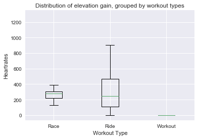

```python
plt.boxplot(EGain)
plt.xlabel('Workout Type')
plt.ylabel('Heartrates')
plt.xticks([1, 2, 3], ['Race', 'Ride', 'Workout'])
plt.title('Distribution of elevation gain, grouped by workout types')
```

Comment: There is no elevation gain in 'Workout', compare to a wider spread in the boxplot 'Ride'.

## Portfolio 2

The goal of the second portfolio is to reproduce some work on predicting the energy usage of a house based on IoT measurements of temperature and humidity and weather observations. It contains:

- An exploration of the data showing the distribution of values of variables that matches some of the plots shown in the first part of the paper.
- Fitting a linear model to the data and generating evaluation metrics (mean squared error, R2)
- Use the sklearn RFE function to apply Recursive Feature Estimation to the data to select the best features, compare with the results described in the paper for the same operation. Compare your results with those in the paper.

#### Import Relevent Packages

```python
import pandas as pd
import numpy as np
from sklearn.model_selection import train_test_split
from sklearn import linear_model
from sklearn.metrics import mean_squared_error, r2_score
import seaborn as sns
import matplotlib.pylab as plt
from datetime import date
from datetime import timedelta
%matplotlib inline
```

#### Loading the data

```python
port2 = pd.read_csv('energydata_complete.csv')
port2.head()
```

|  | date | Appliances | lights | T1 | RH_1 | T2 | RH_2 | T3 | RH_3 | T4 | ... | T9 | RH_9 | T_out | Press_mm_hg | RH_out | Windspeed | Visibility | Tdewpoint | rv1 | rv2 |
| --- | --- | --- | --- | --- | --- | --- | --- | --- | --- | --- | --- | --- | --- | --- | --- | --- | --- | --- | --- | --- | --- |
| 0 | 2016-01-11 17:00:00 | 60 | 30 | 19.89 | 47.596667 | 19.2 | 44.790000 | 19.79 | 44.730000 | 19.000000 | ... | 17.033333 | 45.53 | 6.600000 | 733.5 | 92.0 | 7.000000 | 63.000000 | 5.3 | 13.275433 | 13.275433 |
| 1 | 2016-01-11 17:10:00 | 60 | 30 | 19.89 | 46.693333 | 19.2 | 44.722500 | 19.79 | 44.790000 | 19.000000 | ... | 17.066667 | 45.56 | 6.483333 | 733.6 | 92.0 | 6.666667 | 59.166667 | 5.2 | 18.606195 | 18.606195 |
| 2 | 2016-01-11 17:20:00 | 50 | 30 | 19.89 | 46.300000 | 19.2 | 44.626667 | 19.79 | 44.933333 | 18.926667 | ... | 17.000000 | 45.50 | 6.366667 | 733.7 | 92.0 | 6.333333 | 55.333333 | 5.1 | 28.642668 | 28.642668 |
| 3 | 2016-01-11 17:30:00 | 50 | 40 | 19.89 | 46.066667 | 19.2 | 44.590000 | 19.79 | 45.000000 | 18.890000 | ... | 17.000000 | 45.40 | 6.250000 | 733.8 | 92.0 | 6.000000 | 51.500000 | 5.0 | 45.410389 | 45.410389 |
| 4 | 2016-01-11 17:40:00 | 60 | 40 | 19.89 | 46.333333 | 19.2 | 44.530000 | 19.79 | 45.000000 | 18.890000 | ... | 17.000000 | 45.40 | 6.133333 | 733.9 | 92.0 | 5.666667 | 47.666667 | 4.9 | 10.084097 | 10.084097 |

5 rows × 29 columns

#### Exploratary Data Analysis - EDA

1) Data Type For Each Attribute. From the output below, it shows that most of the data are 'float64 - floating point' while appliances and lights are interger and finally the data is an object. It is important to find out the data type of attributes as we may need to convert some of the data to perform linear/logistic regression.

```python
port2.dtypes
```

```
date            object
Appliances       int64
lights           int64
T1             float64
RH_1           float64
T2             float64
RH_2           float64
T3             float64
RH_3           float64
T4             float64
RH_4           float64
T5             float64
RH_5           float64
T6             float64
RH_6           float64
T7             float64
RH_7           float64
T8             float64
RH_8           float64
T9             float64
RH_9           float64
T_out          float64
Press_mm_hg    float64
RH_out         float64
Windspeed      float64
Visibility     float64
Tdewpoint      float64
rv1            float64
rv2            float64
dtype: object
```

From the output above, it shows most of the datatype of variables are float64 and Appliances and lights are intergers. Additionally, we also noticed that date is object therefore we may need to use a command to convert the date into a time series.

2) Use the commend .describe() to obtain the descriptive statistics of the data. This includes the count, mean, standard deviation, minimum/maximum and the quartiles.

#### Descriptive Statistics for temperature.

```python
dftemp = port2[['T1','T2', 'T3', 'T4', 'T5', 'T6', 'T7', 'T8', 'T9']]
dftemp.describe()
```

|  | T1 | T2 | T3 | T4 | T5 | T6 | T7 | T8 | T9 |
| --- | --- | --- | --- | --- | --- | --- | --- | --- | --- |
| count | 19735.000000 | 19735.000000 | 19735.000000 | 19735.000000 | 19735.000000 | 19735.000000 | 19735.000000 | 19735.000000 | 19735.000000 |
| mean | 21.686571 | 20.341219 | 22.267611 | 20.855335 | 19.592106 | 7.910939 | 20.267106 | 22.029107 | 19.485828 |
| std | 1.606066 | 2.192974 | 2.006111 | 2.042884 | 1.844623 | 6.090347 | 2.109993 | 1.956162 | 2.014712 |
| min | 16.790000 | 16.100000 | 17.200000 | 15.100000 | 15.330000 | -6.065000 | 15.390000 | 16.306667 | 14.890000 |
| 25% | 20.760000 | 18.790000 | 20.790000 | 19.530000 | 18.277500 | 3.626667 | 18.700000 | 20.790000 | 18.000000 |
| 50% | 21.600000 | 20.000000 | 22.100000 | 20.666667 | 19.390000 | 7.300000 | 20.033333 | 22.100000 | 19.390000 |
| 75% | 22.600000 | 21.500000 | 23.290000 | 22.100000 | 20.619643 | 11.256000 | 21.600000 | 23.390000 | 20.600000 |
| max | 26.260000 | 29.856667 | 29.236000 | 26.200000 | 25.795000 | 28.290000 | 26.000000 | 27.230000 | 24.500000 |

```python
dfhum = port2[['RH_1', 'RH_2', 'RH_3', 'RH_4', 'RH_5', 'RH_6', 'RH_7', 'RH_8', 'RH_9']]
dfhum.describe()
```

|  | RH_1 | RH_2 | RH_3 | RH_4 | RH_5 | RH_6 | RH_7 | RH_8 | RH_9 |
| --- | --- | --- | --- | --- | --- | --- | --- | --- | --- |
| count | 19735.000000 | 19735.000000 | 19735.000000 | 19735.000000 | 19735.000000 | 19735.000000 | 19735.000000 | 19735.000000 | 19735.000000 |
| mean | 40.259739 | 40.420420 | 39.242500 | 39.026904 | 50.949283 | 54.609083 | 35.388200 | 42.936165 | 41.552401 |
| std | 3.979299 | 4.069813 | 3.254576 | 4.341321 | 9.022034 | 31.149806 | 5.114208 | 5.224361 | 4.151497 |
| min | 27.023333 | 20.463333 | 28.766667 | 27.660000 | 29.815000 | 1.000000 | 23.200000 | 29.600000 | 29.166667 |
| 25% | 37.333333 | 37.900000 | 36.900000 | 35.530000 | 45.400000 | 30.025000 | 31.500000 | 39.066667 | 38.500000 |
| 50% | 39.656667 | 40.500000 | 38.530000 | 38.400000 | 49.090000 | 55.290000 | 34.863333 | 42.375000 | 40.900000 |
| 75% | 43.066667 | 43.260000 | 41.760000 | 42.156667 | 53.663333 | 83.226667 | 39.000000 | 46.536000 | 44.338095 |
| max | 63.360000 | 56.026667 | 50.163333 | 51.090000 | 96.321667 | 99.900000 | 51.400000 | 58.780000 | 53.326667 |

```python
dfwea = port2[['T_out', 'Press_mm_hg', 'Windspeed', 'Visibility', 'Tdewpoint', 'rv1', 'rv2']]
dfwea.describe()
```

|  | T_out | Press_mm_hg | Windspeed | Visibility | Tdewpoint | rv1 | rv2 |
| --- | --- | --- | --- | --- | --- | --- | --- |
| count | 19735.000000 | 19735.000000 | 19735.000000 | 19735.000000 | 19735.000000 | 19735.000000 | 19735.000000 |
| mean | 7.411665 | 755.522602 | 4.039752 | 38.330834 | 3.760707 | 24.988033 | 24.988033 |
| std | 5.317409 | 7.399441 | 2.451221 | 11.794719 | 4.194648 | 14.496634 | 14.496634 |
| min | -5.000000 | 729.300000 | 0.000000 | 1.000000 | -6.600000 | 0.005322 | 0.005322 |
| 25% | 3.666667 | 750.933333 | 2.000000 | 29.000000 | 0.900000 | 12.497889 | 12.497889 |
| 50% | 6.916667 | 756.100000 | 3.666667 | 40.000000 | 3.433333 | 24.897653 | 24.897653 |
| 75% | 10.408333 | 760.933333 | 5.500000 | 40.000000 | 6.566667 | 37.583769 | 37.583769 |
| max | 26.100000 | 772.300000 | 14.000000 | 66.000000 | 15.500000 | 49.996530 | 49.996530 |

3) We can also conduct correlation coefficients to find out the relationship between variables. This can be achieved by using the .corr command.

```python
port2.corr()
```

|  | Appliances | lights | T1 | RH_1 | T2 | RH_2 | T3 | RH_3 | T4 | RH_4 | ... | T9 | RH_9 | T_out | Press_mm_hg | RH_out | Windspeed | Visibility | Tdewpoint | rv1 | rv2 |
| --- | --- | --- | --- | --- | --- | --- | --- | --- | --- | --- | --- | --- | --- | --- | --- | --- | --- | --- | --- | --- | --- |
| Appliances | 1.000000 | 0.197278 | 0.055447 | 0.086031 | 0.120073 | -0.060465 | 0.085060 | 0.036292 | 0.040281 | 0.016965 | ... | 0.010010 | -0.051462 | 0.099155 | -0.034885 | -0.152282 | 0.087122 | 0.000230 | 0.015353 | -0.011145 | -0.011145 |
| lights | 0.197278 | 1.000000 | -0.023528 | 0.106968 | -0.005622 | 0.050985 | -0.097393 | 0.131161 | -0.008859 | 0.114936 | ... | -0.157592 | -0.008766 | -0.074424 | -0.010576 | 0.068543 | 0.060281 | 0.020038 | -0.036322 | 0.000521 | 0.000521 |
| T1 | 0.055447 | -0.023528 | 1.000000 | 0.164006 | 0.836834 | -0.002509 | 0.892402 | -0.028550 | 0.877001 | 0.097861 | ... | 0.844777 | 0.071756 | 0.682846 | -0.150574 | -0.345481 | -0.087654 | -0.076210 | 0.571309 | -0.006203 | -0.006203 |
| RH_1 | 0.086031 | 0.106968 | 0.164006 | 1.000000 | 0.269839 | 0.797535 | 0.253230 | 0.844677 | 0.106180 | 0.880359 | ... | 0.115263 | 0.764001 | 0.340767 | -0.293957 | 0.274126 | 0.204932 | -0.021057 | 0.639106 | -0.000699 | -0.000699 |
| T2 | 0.120073 | -0.005622 | 0.836834 | 0.269839 | 1.000000 | -0.165610 | 0.735245 | 0.121497 | 0.762066 | 0.231563 | ... | 0.675535 | 0.157346 | 0.792255 | -0.133028 | -0.505291 | 0.052495 | -0.069721 | 0.582602 | -0.011087 | -0.011087 |
| RH_2 | -0.060465 | 0.050985 | -0.002509 | 0.797535 | -0.165610 | 1.000000 | 0.137319 | 0.678326 | -0.047304 | 0.721435 | ... | 0.054544 | 0.676467 | 0.033674 | -0.255646 | 0.584911 | 0.069190 | -0.005368 | 0.499152 | 0.006275 | 0.006275 |
| T3 | 0.085060 | -0.097393 | 0.892402 | 0.253230 | 0.735245 | 0.137319 | 1.000000 | -0.011234 | 0.852778 | 0.122737 | ... | 0.901324 | 0.134602 | 0.699417 | -0.189974 | -0.281718 | -0.100776 | -0.102310 | 0.645886 | -0.005194 | -0.005194 |
| RH_3 | 0.036292 | 0.131161 | -0.028550 | 0.844677 | 0.121497 | 0.678326 | -0.011234 | 1.000000 | -0.140457 | 0.898978 | ... | -0.195270 | 0.833538 | 0.118207 | -0.233274 | 0.356192 | 0.263188 | 0.017041 | 0.414387 | -0.000477 | -0.000477 |
| T4 | 0.040281 | -0.008859 | 0.877001 | 0.106180 | 0.762066 | -0.047304 | 0.852778 | -0.140457 | 1.000000 | -0.048650 | ... | 0.889439 | -0.025549 | 0.663478 | -0.075292 | -0.388602 | -0.185747 | -0.104768 | 0.519471 | -0.001815 | -0.001815 |
| RH_4 | 0.016965 | 0.114936 | 0.097861 | 0.880359 | 0.231563 | 0.721435 | 0.122737 | 0.898978 | -0.048650 | 1.000000 | ... | -0.044518 | 0.856591 | 0.293289 | -0.250748 | 0.336813 | 0.300192 | 0.002636 | 0.616509 | -0.001787 | -0.001787 |
| T5 | 0.019760 | -0.078745 | 0.885247 | 0.205797 | 0.720550 | 0.110409 | 0.888169 | -0.050062 | 0.871813 | 0.091812 | ... | 0.911055 | 0.072308 | 0.651321 | -0.170999 | -0.273953 | -0.145011 | -0.084164 | 0.588362 | -0.005490 | -0.005490 |
| RH_5 | 0.006955 | 0.141233 | -0.014782 | 0.303258 | 0.029595 | 0.250271 | -0.066355 | 0.375422 | -0.076489 | 0.352591 | ... | -0.138509 | 0.272197 | -0.053126 | -0.119327 | 0.185941 | 0.082044 | -0.013133 | 0.078175 | -0.011056 | -0.011056 |
| T6 | 0.117638 | -0.079029 | 0.654769 | 0.316141 | 0.801186 | -0.009670 | 0.686882 | 0.076833 | 0.652350 | 0.259047 | ... | 0.667177 | 0.184424 | 0.974787 | -0.141643 | -0.569119 | 0.169185 | -0.081313 | 0.764242 | -0.015086 | -0.015086 |
| RH_6 | -0.083178 | 0.153756 | -0.615045 | 0.245126 | -0.580372 | 0.389933 | -0.647672 | 0.514912 | -0.703149 | 0.392178 | ... | -0.738940 | 0.391943 | -0.641572 | -0.065814 | 0.718587 | 0.098317 | 0.108705 | -0.260417 | 0.011671 | 0.011671 |
| T7 | 0.025801 | -0.135347 | 0.838705 | 0.021397 | 0.663660 | -0.051422 | 0.847374 | -0.250090 | 0.877763 | -0.131204 | ... | 0.944776 | -0.077690 | 0.631293 | -0.097724 | -0.411213 | -0.185892 | -0.110089 | 0.466625 | -0.003900 | -0.003900 |
| RH_7 | -0.055642 | 0.035069 | 0.135182 | 0.801122 | 0.229212 | 0.690584 | 0.172624 | 0.832685 | 0.043527 | 0.894301 | ... | 0.028055 | 0.858686 | 0.294199 | -0.265850 | 0.378519 | 0.212979 | -0.007184 | 0.641857 | 0.001820 | 0.001820 |
| T8 | 0.039572 | -0.071458 | 0.825413 | -0.030053 | 0.578191 | -0.041023 | 0.795283 | -0.283228 | 0.796256 | -0.167066 | ... | 0.869338 | -0.156820 | 0.502842 | -0.162855 | -0.300438 | -0.218876 | -0.060098 | 0.391810 | -0.003210 | -0.003210 |
| RH_8 | -0.094039 | 0.012915 | -0.006441 | 0.736196 | 0.068534 | 0.679777 | 0.044427 | 0.828822 | -0.095192 | 0.847259 | ... | -0.113014 | 0.855812 | 0.117141 | -0.225591 | 0.487355 | 0.202380 | 0.046178 | 0.501775 | 0.004480 | 0.004480 |
| T9 | 0.010010 | -0.157592 | 0.844777 | 0.115263 | 0.675535 | 0.054544 | 0.901324 | -0.195270 | 0.889439 | -0.044518 | ... | 1.000000 | -0.008683 | 0.668220 | -0.156828 | -0.318848 | -0.177756 | -0.103915 | 0.581483 | -0.001227 | -0.001227 |
| RH_9 | -0.051462 | -0.008766 | 0.071756 | 0.764001 | 0.157346 | 0.676467 | 0.134602 | 0.833538 | -0.025549 | 0.856591 | ... | -0.008683 | 1.000000 | 0.223270 | -0.183739 | 0.359377 | 0.238655 | 0.008667 | 0.540328 | -0.002955 | -0.002955 |
| T_out | 0.099155 | -0.074424 | 0.682846 | 0.340767 | 0.792255 | 0.033674 | 0.699417 | 0.118207 | 0.663478 | 0.293289 | ... | 0.668220 | 0.223270 | 1.000000 | -0.143249 | -0.574197 | 0.192936 | -0.077367 | 0.790661 | -0.015216 | -0.015216 |
| Press_mm_hg | -0.034885 | -0.010576 | -0.150574 | -0.293957 | -0.133028 | -0.255646 | -0.189974 | -0.233274 | -0.075292 | -0.250748 | ... | -0.156828 | -0.183739 | -0.143249 | 1.000000 | -0.092017 | -0.235032 | 0.040315 | -0.244098 | 0.000699 | 0.000699 |
| RH_out | -0.152282 | 0.068543 | -0.345481 | 0.274126 | -0.505291 | 0.584911 | -0.281718 | 0.356192 | -0.388602 | 0.336813 | ... | -0.318848 | 0.359377 | -0.574197 | -0.092017 | 1.000000 | -0.176458 | 0.083125 | 0.036506 | 0.020441 | 0.020441 |
| Windspeed | 0.087122 | 0.060281 | -0.087654 | 0.204932 | 0.052495 | 0.069190 | -0.100776 | 0.263188 | -0.185747 | 0.300192 | ... | -0.177756 | 0.238655 | 0.192936 | -0.235032 | -0.176458 | 1.000000 | -0.007516 | 0.125972 | -0.011342 | -0.011342 |
| Visibility | 0.000230 | 0.020038 | -0.076210 | -0.021057 | -0.069721 | -0.005368 | -0.102310 | 0.017041 | -0.104768 | 0.002636 | ... | -0.103915 | 0.008667 | -0.077367 | 0.040315 | 0.083125 | -0.007516 | 1.000000 | -0.042190 | -0.005889 | -0.005889 |
| Tdewpoint | 0.015353 | -0.036322 | 0.571309 | 0.639106 | 0.582602 | 0.499152 | 0.645886 | 0.414387 | 0.519471 | 0.616509 | ... | 0.581483 | 0.540328 | 0.790661 | -0.244098 | 0.036506 | 0.125972 | -0.042190 | 1.000000 | -0.003943 | -0.003943 |
| rv1 | -0.011145 | 0.000521 | -0.006203 | -0.000699 | -0.011087 | 0.006275 | -0.005194 | -0.000477 | -0.001815 | -0.001787 | ... | -0.001227 | -0.002955 | -0.015216 | 0.000699 | 0.020441 | -0.011342 | -0.005889 | -0.003943 | 1.000000 | 1.000000 |
| rv2 | -0.011145 | 0.000521 | -0.006203 | -0.000699 | -0.011087 | 0.006275 | -0.005194 | -0.000477 | -0.001815 | -0.001787 | ... | -0.001227 | -0.002955 | -0.015216 | 0.000699 | 0.020441 | -0.011342 | -0.005889 | -0.003943 | 1.000000 | 1.000000 |

28 rows × 28 columns

The first step is to recreate the date into index - otherwise we cannot create a plot. Recall the first step of EDA, it shows the default datatype of date is an object.

```python
port2['date'] = pd.to_datetime(port2['date'])
```

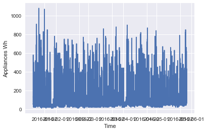

```python
date = port2['date']
Appliances = port2['Appliances']
plt.plot(date, Appliances)
plt.xlabel('Time')
plt.ylabel('Appliances Wh')
```

#### Fiqure 8: Appliances energy consumption distribution. Top: Histogram shows the frequency of energy consumption in the interval (bar width), and the boxplot shows the location of the median with the black line.

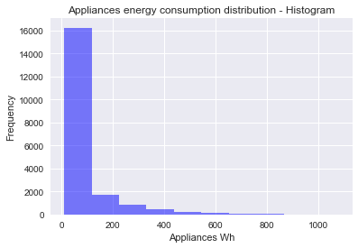

```python
bins = 40
plt.hist(port2['Appliances'], facecolor='blue', alpha=0.5)
plt.xlabel('Appliances Wh')
plt.ylabel('Frequency')
plt.title('Appliances energy consumption distribution - Histogram')
```

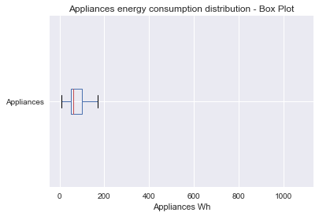

```python
port2.boxplot(column = 'Appliances', vert=False)
plt.xlabel('Appliances Wh')
plt.title('Appliances energy consumption distribution - Box Plot')
```

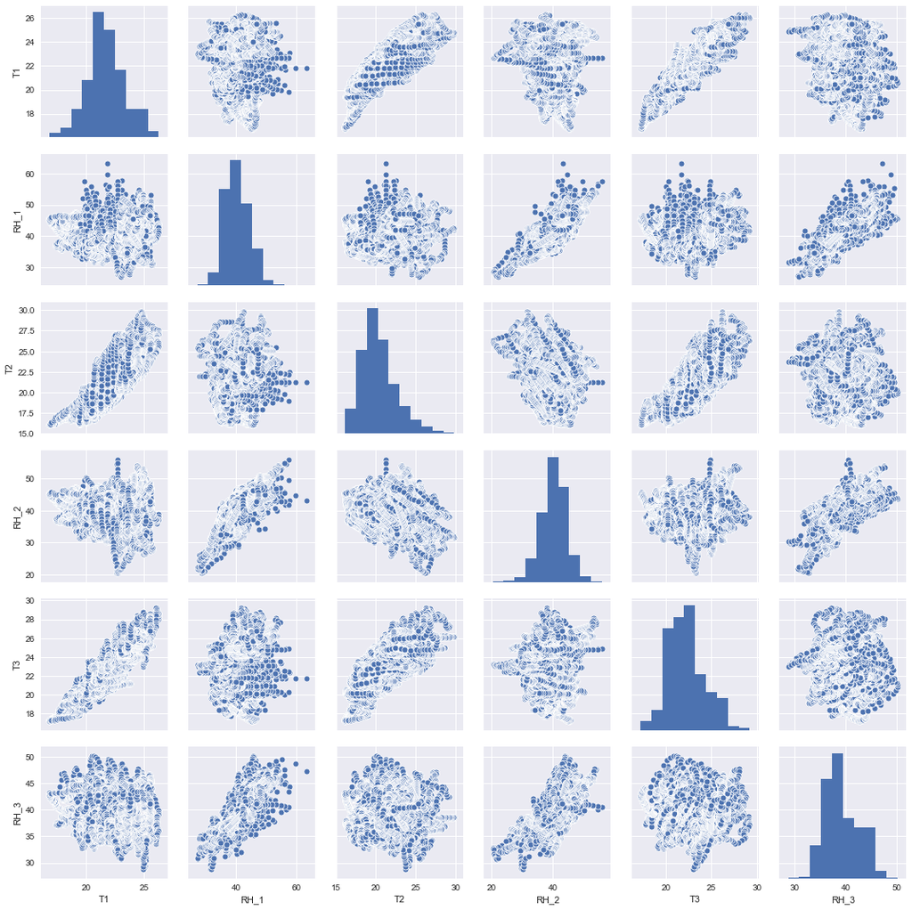

```python
fig9 = port2[['T1', 'RH_1', 'T2', 'RH_2', 'T3', 'RH_3']]
sns.pairplot(fig9)
```

```python
fig9.corr()
```

|  | T1 | RH_1 | T2 | RH_2 | T3 | RH_3 |
| --- | --- | --- | --- | --- | --- | --- |
| T1 | 1.000000 | 0.164006 | 0.836834 | -0.002509 | 0.892402 | -0.028550 |
| RH_1 | 0.164006 | 1.000000 | 0.269839 | 0.797535 | 0.253230 | 0.844677 |
| T2 | 0.836834 | 0.269839 | 1.000000 | -0.165610 | 0.735245 | 0.121497 |
| RH_2 | -0.002509 | 0.797535 | -0.165610 | 1.000000 | 0.137319 | 0.678326 |
| T3 | 0.892402 | 0.253230 | 0.735245 | 0.137319 | 1.000000 | -0.011234 |
| RH_3 | -0.028550 | 0.844677 | 0.121497 | 0.678326 | -0.011234 | 1.000000 |

Multiple Regression - Using all the varaibles that is in the complete dataset.

```python
reg = linear_model.LinearRegression()
x = port2[['lights', 'T1', 'RH_1', 'T2', 'RH_2', 'T3', 'RH_3', 'T4', 'RH_4', 'T5', 'RH_5', 'T6', 'RH_6', 'T7', 'RH_7', 'T8', 'RH_8', 'T9', 'RH_9', 'T_out', 'Press_mm_hg', 'RH_out', 'Windspeed', 'Visibility', 'Tdewpoint', 'rv1', 'rv2']]
y = port2['Appliances']
reg.fit(x, y)
print("y = x *", reg.coef_, "+", reg.intercept_)
```

```
y = x * [ 1.98970872e+00 -6.03740447e-01  1.51536202e+01 -1.77060184e+01
 -1.34806196e+01  2.54063968e+01  4.92457103e+00 -3.46525259e+00
 -1.78907733e-01 -2.78433827e-02  1.40960661e-01  7.12616274e+00
  2.87947692e-01  1.79462806e+00 -1.54968445e+00  8.14656214e+00
 -4.66967684e+00 -1.58724297e+01 -9.01020672e-01 -1.02281901e+01
  1.39856191e-01 -1.06374667e+00  1.70363647e+00  1.53681019e-01
  5.04880144e+00 -2.07763425e-02 -2.07763425e-02] + 50.2084365968783
```

Calculate the residuals

```python
predicted = reg.predict(x)
print("MSE:", mean_squared_error(y, predicted))
print("R^2:", r2_score(y, predicted))
```

```
MSE: 8777.519929754457
R^2: 0.16490630926307814
```

#### Set up RFE (Recursive Feature Elimination)

- Select all the variables and form an array.
- Define the X (Independent) and Y (Dependent Variables)
- We manually split the data into training and testing data. Based on the paper, the authors have used 75% of the data as training and 25% to be testing data.
- Import LinearRegression, RFE and Mean_Squared_Error (MSE) and R^2 as our metrics for regreesion. Both MSE and R^2 will determine how well our model fits.
- Note that, the complete dataset (energy_completed.csv) is used in this analysis. On the other hand, the authors have used the separate datasets (both training and test) to conduct RFE - as a result there may be a sight variation of the result.

```python
feature_cols = np.array(['lights', 'T1', 'RH_1', 'T2', 'RH_2', 'T3', 'RH_3', 'T4', 'RH_4', 'T5', 'RH_5', 'T6', 'RH_6', 'T7', 'RH_7', 'T8', 'RH_8', 'T9', 'RH_9', 'T_out', 'Press_mm_hg', 'RH_out', 'Windspeed', 'Visibility', 'Tdewpoint', 'rv1', 'rv2'])
X = port2[feature_cols]
y = port2['Appliances']
X_train, X_test, y_train, y_test = train_test_split(X, y, test_size=0.25)
```

```python
from sklearn.linear_model import LinearRegression
from sklearn.feature_selection import RFE
from sklearn.metrics import mean_squared_error, r2_score


estimator = LinearRegression()
selector = RFE(estimator, 32) #We asked RFE to select 32 features.
selector = selector.fit(X, y)

supp = selector.get_support()
print("Selected features:", feature_cols[supp])
print("Coeffs:", selector.estimator_.coef_)
# test the model
predicted = selector.predict(X)
print("MSE:", mean_squared_error(y, predicted))
print("R^2:", r2_score(y, predicted))
```

```
Selected features: ['lights' 'T1' 'RH_1' 'T2' 'RH_2' 'T3' 'RH_3' 'T4' 'RH_4' 'T5' 'RH_5' 'T6'
 'RH_6' 'T7' 'RH_7' 'T8' 'RH_8' 'T9' 'RH_9' 'T_out' 'Press_mm_hg' 'RH_out'
 'Windspeed' 'Visibility' 'Tdewpoint' 'rv1' 'rv2']
Coeffs: [ 1.98970872e+00 -6.03740447e-01  1.51536202e+01 -1.77060184e+01
 -1.34806196e+01  2.54063968e+01  4.92457103e+00 -3.46525259e+00
 -1.78907733e-01 -2.78433827e-02  1.40960661e-01  7.12616274e+00
  2.87947692e-01  1.79462806e+00 -1.54968445e+00  8.14656214e+00
 -4.66967684e+00 -1.58724297e+01 -9.01020672e-01 -1.02281901e+01
  1.39856191e-01 -1.06374667e+00  1.70363647e+00  1.53681019e-01
  5.04880144e+00 -2.07763425e-02 -2.07763425e-02]
MSE: 8777.519929754457
R^2: 0.16490630926307814
```

#### Interpretation of results.

- Based on the R^2 of the model, it shows that 16.4% of the data are explained by using our data. In other words, regression is prehaps not the best technique to use in this dataset. Additionally, we can also look at the coefficients of the features to determine how RFE ranks them in regards of significance.

#### Further Regression Analysis - Using Training and Testing Data

```python
train = pd.read_csv('training.csv')
test = pd.read_csv('testing.csv')
train.shape, test.shape
```

```
((14803, 32), (4932, 32))
```

Load both training and testing dataset and check the number of observations.

```python
train.info()
```

```
<class 'pandas.core.frame.DataFrame'>
RangeIndex: 14803 entries, 0 to 14802
Data columns (total 32 columns):
date           14803 non-null object
Appliances     14803 non-null int64
lights         14803 non-null int64
T1             14803 non-null float64
RH_1           14803 non-null float64
T2             14803 non-null float64
RH_2           14803 non-null float64
T3             14803 non-null float64
RH_3           14803 non-null float64
T4             14803 non-null float64
RH_4           14803 non-null float64
T5             14803 non-null float64
RH_5           14803 non-null float64
T6             14803 non-null float64
RH_6           14803 non-null float64
T7             14803 non-null float64
RH_7           14803 non-null float64
T8             14803 non-null float64
RH_8           14803 non-null float64
T9             14803 non-null float64
RH_9           14803 non-null float64
T_out          14803 non-null float64
Press_mm_hg    14803 non-null float64
RH_out         14803 non-null float64
Windspeed      14803 non-null float64
Visibility     14803 non-null float64
Tdewpoint      14803 non-null float64
rv1            14803 non-null float64
rv2            14803 non-null float64
NSM            14803 non-null int64
WeekStatus     14803 non-null object
Day_of_week    14803 non-null object
dtypes: float64(26), int64(3), object(3)
memory usage: 3.6+ MB
```

```python
test.info()
```

```
<class 'pandas.core.frame.DataFrame'>
RangeIndex: 4932 entries, 0 to 4931
Data columns (total 32 columns):
date           4932 non-null object
Appliances     4932 non-null int64
lights         4932 non-null int64
T1             4932 non-null float64
RH_1           4932 non-null float64
T2             4932 non-null float64
RH_2           4932 non-null float64
T3             4932 non-null float64
RH_3           4932 non-null float64
T4             4932 non-null float64
RH_4           4932 non-null float64
T5             4932 non-null float64
RH_5           4932 non-null float64
T6             4932 non-null float64
RH_6           4932 non-null float64
T7             4932 non-null float64
RH_7           4932 non-null float64
T8             4932 non-null float64
RH_8           4932 non-null float64
T9             4932 non-null float64
RH_9           4932 non-null float64
T_out          4932 non-null float64
Press_mm_hg    4932 non-null float64
RH_out         4932 non-null float64
Windspeed      4932 non-null float64
Visibility     4932 non-null float64
Tdewpoint      4932 non-null float64
rv1            4932 non-null float64
rv2            4932 non-null float64
NSM            4932 non-null int64
WeekStatus     4932 non-null object
Day_of_week    4932 non-null object
dtypes: float64(26), int64(3), object(3)
memory usage: 1.2+ MB
```

By looking at the data type of each variables, it shows that variables 'WeekStatus' and 'Day_of_week' are categorical variables.Therefore we might need to convert them into a dummy variable (either 0 for weekday or 1 weekend) to conduct regression analysis for both training data set.

```python
train1 = pd.get_dummies(train, columns=['WeekStatus'])
train1.info()
```

```
<class 'pandas.core.frame.DataFrame'>
RangeIndex: 14803 entries, 0 to 14802
Data columns (total 33 columns):
date                  14803 non-null object
Appliances            14803 non-null int64
lights                14803 non-null int64
T1                    14803 non-null float64
RH_1                  14803 non-null float64
T2                    14803 non-null float64
RH_2                  14803 non-null float64
T3                    14803 non-null float64
RH_3                  14803 non-null float64
T4                    14803 non-null float64
RH_4                  14803 non-null float64
T5                    14803 non-null float64
RH_5                  14803 non-null float64
T6                    14803 non-null float64
RH_6                  14803 non-null float64
T7                    14803 non-null float64
RH_7                  14803 non-null float64
T8                    14803 non-null float64
RH_8                  14803 non-null float64
T9                    14803 non-null float64
RH_9                  14803 non-null float64
T_out                 14803 non-null float64
Press_mm_hg           14803 non-null float64
RH_out                14803 non-null float64
Windspeed             14803 non-null float64
Visibility            14803 non-null float64
Tdewpoint             14803 non-null float64
rv1                   14803 non-null float64
rv2                   14803 non-null float64
NSM                   14803 non-null int64
Day_of_week           14803 non-null object
WeekStatus_Weekday    14803 non-null uint8
WeekStatus_Weekend    14803 non-null uint8
dtypes: float64(26), int64(3), object(2), uint8(2)
memory usage: 3.5+ MB
```

```python
reg1 = linear_model.LinearRegression()
x_train = train1[['lights', 'T1', 'RH_1', 'T2', 'RH_2', 'T3', 'RH_3', 'T4', 'RH_4', 'T5', 'RH_5', 'T6', 'RH_6', 'T7', 'RH_7', 'T8', 'RH_8', 'T9', 'RH_9', 'T_out', 'Press_mm_hg', 'RH_out', 'Windspeed', 'Visibility', 'Tdewpoint', 'rv1', 'rv2', 'NSM', 'WeekStatus_Weekday', 'WeekStatus_Weekend']]
y_train = train1['Appliances']
reg1.fit(x_train,y_train)
print("y = x *", reg1.coef_, "+", reg1.intercept_)
```

```
y = x * [ 1.86461679e+00 -4.46091597e+00  1.44907462e+01 -1.79316039e+01
 -1.37050058e+01  2.78815065e+01  5.49166703e+00 -1.41621939e+00
 -6.67796334e-01 -1.60801549e+00  8.86676466e-02  7.37960880e+00
  3.39570392e-01  2.53687821e+00 -1.85047606e+00  7.01027944e+00
 -3.68981117e+00 -1.34024918e+01 -4.37745160e-01 -1.05256219e+01
  1.67528904e-01 -9.76684794e-01  1.71012995e+00  1.63817779e-01
  4.51418909e+00 -2.54488380e-02 -2.54488380e-02  2.96705995e-04
 -4.45092789e+00  4.45092789e+00] + -20.876255414537397
```

```python
predicted2 = reg1.predict(x_train)
print("MSE:", mean_squared_error(y_train, predicted2))
print("R^2:", r2_score(y_train, predicted2))
```

```
MSE: 8741.73112387285
R^2: 0.1731935745364661
```

```python
test1 = pd.get_dummies(test, columns=['WeekStatus'])
test1.info()
```

```
<class 'pandas.core.frame.DataFrame'>
RangeIndex: 4932 entries, 0 to 4931
Data columns (total 33 columns):
date                  4932 non-null object
Appliances            4932 non-null int64
lights                4932 non-null int64
T1                    4932 non-null float64
RH_1                  4932 non-null float64
T2                    4932 non-null float64
RH_2                  4932 non-null float64
T3                    4932 non-null float64
RH_3                  4932 non-null float64
T4                    4932 non-null float64
RH_4                  4932 non-null float64
T5                    4932 non-null float64
RH_5                  4932 non-null float64
T6                    4932 non-null float64
RH_6                  4932 non-null float64
T7                    4932 non-null float64
RH_7                  4932 non-null float64
T8                    4932 non-null float64
RH_8                  4932 non-null float64
T9                    4932 non-null float64
RH_9                  4932 non-null float64
T_out                 4932 non-null float64
Press_mm_hg           4932 non-null float64
RH_out                4932 non-null float64
Windspeed             4932 non-null float64
Visibility            4932 non-null float64
Tdewpoint             4932 non-null float64
rv1                   4932 non-null float64
rv2                   4932 non-null float64
NSM                   4932 non-null int64
Day_of_week           4932 non-null object
WeekStatus_Weekday    4932 non-null uint8
WeekStatus_Weekend    4932 non-null uint8
dtypes: float64(26), int64(3), object(2), uint8(2)
memory usage: 1.2+ MB
```

```python
reg2 = linear_model.LinearRegression()
x_test = test1[['lights', 'T1', 'RH_1', 'T2', 'RH_2', 'T3', 'RH_3', 'T4', 'RH_4', 'T5', 'RH_5', 'T6', 'RH_6', 'T7', 'RH_7', 'T8', 'RH_8', 'T9', 'RH_9', 'T_out', 'Press_mm_hg', 'RH_out', 'Windspeed', 'Visibility', 'Tdewpoint', 'rv1', 'rv2', 'NSM', 'WeekStatus_Weekday', 'WeekStatus_Weekend']]
y_test = test1['Appliances']
reg1.fit(x_test,y_test)
print("y = x *", reg1.coef_, "+", reg1.intercept_)
```

```
y = x * [ 2.02435850e+00  2.39108851e+00  1.44867455e+01 -1.83732816e+01
 -1.22884955e+01  2.12928028e+01  3.40729150e+00 -4.32433165e+00
 -7.34052001e-01  2.84483695e+00 -3.62273559e-02  8.02860159e+00
  1.65246561e-01  1.32270852e+00 -8.84228206e-01  4.62628755e+00
 -4.16301993e+00 -1.29595061e+01  2.83014135e-01 -1.00528015e+01
  3.80325957e-03 -6.87163116e-01  1.66530594e+00  2.16822903e-01
  2.81315516e+00 -9.50327728e-03 -9.50327728e-03  2.98019304e-04
 -1.99491748e+00  1.99491748e+00] + 121.17969199303184
```

Similarly, we also to conduct the MSE and R^2 of the model. By observing the results, it appears that both of the numbers are similar to the ones in the paper - which is a good sign.

```python
predicted3 = reg1.predict(x_test)
print("MSE:", mean_squared_error(y_test, predicted3))
print("R^2:", r2_score(y_test, predicted3))
```

```
MSE: 8697.434131431006
R^2: 0.15749732162797092
```

## Portfolio 3

K-means clustering is one of the simplest and popular unsupervised learning algorithms. Typically, unsupervised algorithms make inferences from datasets using only input vectors without referring to known, or labelled, outcomes. This notebook illustrates the process of K-means clustering by generating some random clusters of data and then showing the iterations of the algorithm as random cluster means are updated.

We first generate random data around 4 centers.

#### Import Relevent Packages

```python
import numpy as np
import pandas as pd
from matplotlib import pyplot as plt
%matplotlib inline
```

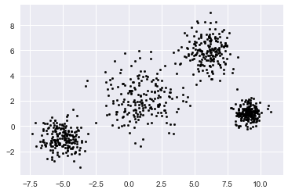

```python
center_1 = np.array([1,2])
center_2 = np.array([6,6])
center_3 = np.array([9,1])
center_4 = np.array([-5,-1])

# Generate random data and center it to the four centers each with a different variance
np.random.seed(5)
data_1 = np.random.randn(200,2) * 1.5 + center_1
data_2 = np.random.randn(200,2) * 1 + center_2
data_3 = np.random.randn(200,2) * 0.5 + center_3
data_4 = np.random.randn(200,2) * 0.8 + center_4

data = np.concatenate((data_1, data_2, data_3, data_4), axis = 0)

plt.scatter(data[:,0], data[:,1], s=7, c='k')
plt.show()
```

#### Question 1: Generate random cluster centres

You need to generate four random centres.

This part of portfolio should contain at least:

- The number of clusters `k` is set to 4;
- Generate random centres via `centres = np.random.randn(k,c)*std + mean` where `std` and `mean` are the standard deviation and mean of the data. `c` represents the number of features in the data. Set the random seed to 6.
- Color the generated centers with `green`, `blue`, `yellow`, and `cyan`. Set the edgecolors to `red`.

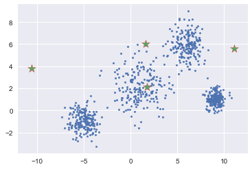

```python
k = 4
n = data.shape[0]
c = data.shape[1]
color = ['green', 'blue', 'yellow', 'cyan']
mean = np.mean(data, axis = 0)
std = np.std(data, axis = 0)
centers = np.random.randn(k,c)*std + mean
plt.scatter(data[:,0], data[:,1], s=7)
plt.scatter(centers[:,0], centers[:,1], marker='*', c= None, s=150, edgecolors= 'red')
```

#### Question 2: Visualise the clustering results in each iteration

You need to implement the process of k-means clustering. Implement each iteration as a seperate cell, assigning each data point to the closest centre, then updating the cluster centres based on the data, then plot the new clusters.

We are going to gernerate some random data for our data set and the centriod.

```python
x = np.random.rand(100,2)

z1 = np.random.rand(1,2)
z2 = np.random.rand(1,2)
z3 = np.random.rand(1,2)
```

We then calculate the distances between each of the data points and assign them to cloest distance.

```python
c = np.zeros(len(x))
for i in range(len(x)):
    dist1 = np.linalg.norm(x[i] - z1)
    dist2 = np.linalg.norm(x[i] - z2)
    dist3 = np.linalg.norm(x[i] - z3)
    min_dist = min(dist1,dist2,dist3)
    if min_dist == dist1:
        c[i] = 1
    elif min_dist == dist2:
        c[i] = 2
    else: # min_dist == dist3:
        c[i] = 3
```